# **Real-world Data Wrangling**

## **1.** Gather data

```python
# Importing libraries.
import numpy as np
import pandas as pd
import matplotlib.pyplot as plt
import seaborn as sns
from bs4 import BeautifulSoup
```

### **1.1.** Problem Statement

At Kitty of Angels, a 501(c)(3) non-profit devoted to supporting homeless cats and kittens in Los Angeles, understanding our foster system's intricacies is crucial to our mission. My primary objective in analyzing the 'intakes' and 'outcomes' datasets is to determine how factors such as a cat or kitten's sex and breed correlate with its length of stay in our foster system. By delving deep into these variables, I aim to uncover patterns or insights that could help optimize our operations, ensuring that every feline under our care finds a loving home in the shortest possible time.

### **1.2.** Gather at least two datasets using two different data gathering methods

### **Dataset 1**

**Type:**

- CSV

**Method:**

- The data was manually downloaded through an exported Excel report from Shelterluv.com. This report was then converted to CSV and loaded through pd.read_csv().

Dataset variables:

- Intake Date Animal
- ID
- Name
- Species
- Primary Breed
- Secondary Breed
- Sex
- Altered
- Intake Type
- Intake Sub-Type
- Intake By
- Intake From (ID)
- Intake From Name

```python
# Reading the raw DataFrame.
df_intakes_raw = pd.read_csv('intakes.csv')

# Saving the raw DataFrame to a CSV file.
df_intakes_raw.to_csv('intakes_raw.csv', index=False)
```

### **Dataset 2**

**Type:**

- Extracted from HTML using BeautifulSoup

**Method:**

- The data was gathered through an HTML document of a report on ShelterLuv.com. The data was then extracted from the HTML document using BeautifulSoup.

**Dataset variables:**

- Outcome Date
- Outcome Time
- Animal ID
- Name
- Species
- Primary Breed
- Secondary Breed
- Sex
- Altered
- Outcome Type
- Outcome Sub-Type
- Last Foster Location
- Assoc Person ID Assoc.
- Person Name
- Outcome By

```python
# Reading the data from the html file.
with open('Foster_Outcomes_Shelterluv.html', 'r', encoding='utf-8') as f:
    html_content = f.read()

# Parsing the html content.
soup = BeautifulSoup(html_content, 'html.parser')

# Extracting the second table, which contains the appropriate data.
tables = soup.find_all('table')
data_table = tables[1]

# Extracting the headers and rows from the second table.
header = [th.get_text().strip() for th in data_table.find('tr').find_all('th')]
rows = data_table.find_all('tr')[1:]  # Exclude header row

# Converting the extracted data into a DataFrame using the headers and rows.
df_outcomes_raw = pd.DataFrame([[td.get_text().strip() for td in row.find_all('td')] for row in rows], columns=header)

# Saving the raw DataFrame to 'outcomes_raw.csv'.
df_outcomes_raw.to_csv('outcomes_raw.csv', index=False)
```

## **2.** Assess data

## Assessing Quality Issues in the 'intakes'

### Quality Issue 1: Validity

**Issue:**

- Some columns in the dataset contain sensitive or private information that could compromise the privacy of individuals or entities. These columns are 'Intake By', 'Intake From (ID)', and 'Intake From Name'. Furthermore, given the number of unique values in 'Intake From Name', there are many individuals whose privacy should be safeguarded. If the number were smaller, it might be viable to contact them for persmission. Another issue concerning validity is the data type of the 'Intake Date' column, which is set as 'object' and will be changed to 'datetime64[ns]'.

**Justification:**

- Solving this issue ensures adherance to ethical data handling practices and also ensures the dataset's validity for public use. Furthermore, changing the data type of the 'Intake Date' will allow for deeper analysis when the 'intakes' and 'outcomes' dataframes are merged.

```python
# Inspecting the dataframe visually. Because of data privacy, '.head(0)' is used to hide the data.
df_intakes_raw.head(0)
```

|  | Intake Date | Animal ID | Name | Species | Primary Breed | Secondary Breed | Sex | Altered | Intake Type | Intake Sub-Type | Intake By | Intake From (ID) | Intake From Name |
| --- | --- | --- | --- | --- | --- | --- | --- | --- | --- | --- | --- | --- | --- |

```python
# Inspecting the dataframe programmatically

# Defining a new variable to store the columns with privacy concerns.
privacy_columns = ['Intake By', 'Intake From (ID)', 'Intake From Name']

# Printing the number of unique values in the 'privacy_columns' variable.
for col in privacy_columns:
    print(f"Unique values in {col}: {df_intakes_raw[col].nunique()}\n")
```

```
Unique values in Intake By: 4

Unique values in Intake From (ID): 47

Unique values in Intake From Name: 48
```

### Quality Issue 2: Completeness

**Issue:**

- The dataset exhibits issues with completeness. Specific columns, such as 'Secondary Breed' and 'Intake Sub-Type', have a notable number of missing values. Their presence not only poses challenges in analysis but also indicates that the records are not fully populated. Additionally, the presence of irrelevant rows can cloud the analysis and lead to skewed results. Furthermore, there are values of 'Unknown' in the 'Sex' column and 'nan' in the 'Primary Breed' column.

**Justification:**

- The programmatic inspection reveals specific columns with high counts of missing values, reinforcing the decision to remove or address these columns for a more complete dataset. By addressing columns with a significant number of missing values and by removing the 'Unknown' and 'nan' values, we can streamline our dataset for a more focused analysis.

```python
# Checking the number of unique values in each column.
columns_to_drop = ['Secondary Breed', 'Altered', 'Intake Sub-Type']

# Checking the number of missing values in each column.
for col in columns_to_drop:
    missing_values = df_intakes_raw[col].isnull().sum()
    print(f"Missing values in {col}: {missing_values}")

    # Checking the distribution of values in these columns.
    value_counts = df_intakes_raw[col].value_counts()
    print(f"Value distribution in {col}:\n{value_counts}\n")
```

```
Missing values in Secondary Breed: 1366
Value distribution in Secondary Breed:
Secondary Breed
Mix                          9
Russian Blue                 2
Siamese                      2
Chihuahua, Short Coat        2
Egyptian Mau                 1
Himalayan                    1
Retriever, Black Labrador    1
Pointer, English             1
Name: count, dtype: int64

Missing values in Altered: 0
Value distribution in Altered:
Altered
Yes                 1104
To be determined     274
No                     7
Name: count, dtype: int64

Missing values in Intake Sub-Type: 1244
Value distribution in Intake Sub-Type:
Intake Sub-Type
Within Coalition             130
Born In Care                   4
Outside Coalition              2
Owner Health                   2
Landlord / Housing Issues      2
Transfer In                    1
Name: count, dtype: int64
```

```python
# Printing the unique values in 'Sex' and 'Primary Breed'.
print(df_intakes_raw['Sex'].unique())
print(df_intakes_raw['Primary Breed'].unique())
```

```
['Female' 'Male' 'Unknown']
['Domestic Shorthair' 'Domestic Medium Hair' 'Domestic Longhair' 'Siamese'
 'Russian Blue' 'Nebelung' 'American Shorthair' 'Ragdoll' 'Maine Coon'
 'Mixed Breed (Large)' nan 'Retriever, Black Labrador' 'Chihuahua'
 'Terrier, American Staffordshire']
```

```python
# Calculating the number of 'Unknown' values in the 'Sex' column, accounting for case sensitivity.
unknown_sex_count = (df_intakes_raw['Sex'].str.lower() == 'unknown').sum()

# Calculating the number of 'nan' values in the 'Primary Breed' column.
nan_breed_count = df_intakes_raw['Primary Breed'].isna().sum()

# Printing the calculated values.
print(f"Number of 'Unknown' values in 'Sex' column: {unknown_sex_count}")
print(f"Number of NaN values in 'Primary Breed' column: {nan_breed_count}")
```

```
Number of 'Unknown' values in 'Sex' column: 54
Number of NaN values in 'Primary Breed' column: 11
```

### Quality Issue 3: Relevancy

**Issue:**

- The dataset contains records for multiple species in the Species column. For the purpose of this analysis, only records related to cats are relevant. As such, entries pertaining to 'Dog' and 'Hamster, Dwarf' should be removed to streamline the dataset.

Justification:

- By excluding data related to dogs, we concentrate solely on the patterns and insights related to cats. After this filtering, the Species column becomes extraneous, as it will contain a single unique value, 'Cat'. Removing such a column not only simplifies the dataset but also enhances its efficiency in terms of storage and processing. This aligns with the principle of relevancy in data wrangling, ensuring that only pertinent data is retained for analysis.

```python
# Listing the unique values in the 'species' column.
df_intakes_raw['Species'].unique()
```

```
array(['Cat', 'Dog', 'Hamster, Dwarf'], dtype=object)
```

```python
# Listing the value counts of each unique value in the 'species' column.
df_intakes_raw['Species'].value_counts()
```

```
Species
Cat               1375
Dog                  6
Hamster, Dwarf       4
Name: count, dtype: int64
```

## Assessing Quality Issues in 'outcomes'

### Quality Issue 1: Validity

**Issue:**

**Justification:**

```python
# Inspecting the dataframe visually. For data privacy, '.head(0)' is used to hide the sensitive data.
df_outcomes_raw.head(0)
```

|  | Outcome Date | Outcome Time | Animal ID | Name | Species | Primary Breed | Secondary Breed | Sex | Altered | Outcome Type | Outcome Sub-Type | Last Foster Location | Assoc Person ID | Assoc. Person Name | Outcome By |
| --- | --- | --- | --- | --- | --- | --- | --- | --- | --- | --- | --- | --- | --- | --- | --- |

```python
# Checking the data types of the columns, specifically the 'Outcome Date' column.
df_outcomes_raw.dtypes
```

```
Outcome Date            object
Outcome Time            object
Animal ID               object
Name                    object
Species                 object
Primary Breed           object
Secondary Breed         object
Sex                     object
Altered                 object
Outcome Type            object
Outcome Sub-Type        object
Last Foster Location    object
Assoc Person ID         object
Assoc. Person Name      object
Outcome By              object
dtype: object
```

### Quality Issue 2: Completeness

**Issue:**

- The 'outcomes' dataset exhibits issues with completeness. Specifically, in the 'Secondary Breed' column, a vast majority of the values are missing. This issue not only poses challenges in analysis but also indicates that the records are not fully populated.

**Justification:**

- The programmatic inspection through '.value_counts()' reveals high counts of missing values, reinforcing the decision to remove or address this column for a more complete dataset.

```python
# Checking for missing values in the 'Secondary Breed'column.
df_outcomes_raw['Secondary Breed'].isnull().sum()
```

```
0
```

```python
# Showing the unique values in the 'Secondary Breed'column.
df_outcomes_raw['Secondary Breed'].unique()
```

```
array(['', 'Egyptian Mau', 'Himalayan', 'Mix', 'Siamese',
       'Pointer, English', 'Chihuahua, Short Coat',
       'Retriever, Black Labrador'], dtype=object)
```

```python
# Calculating the sum of values in the 'Secondary Breed'column.
df_outcomes_raw['Secondary Breed'].value_counts()
```

```
Secondary Breed
                             1283
Mix                             8
Siamese                         2
Chihuahua, Short Coat           2
Egyptian Mau                    1
Himalayan                       1
Pointer, English                1
Retriever, Black Labrador       1
Name: count, dtype: int64
```

### Quality Issue 3: Relevancy

**Issue:**

- This is the same issue as in 'intakes'. The dataset contains records for multiple species in the Species column. For the purpose of this analysis, only records related to cats are relevant. As such, entries pertaining to 'Dog' and 'Hamster, Dwarf' should be removed to streamline the dataset.

Justification:

- By excluding data related to dogs, we concentrate solely on the patterns and insights related to cats. After this filtering, the Species column becomes extraneous, as it will contain a single unique value, 'Cat'. Removing such a column not only simplifies the dataset but also enhances its efficiency in terms of storage and processing. This aligns with the principle of relevancy in data wrangling, ensuring that only pertinent data is retained for analysis.

```python
# Checking for the total number of duplicates.
print(f"Number of duplicate rows: {df_outcomes_raw.duplicated().sum()}")

# Checking the total number of unique values in the 'species' column.
df_outcomes_raw['Species'].unique()
df_outcomes_raw['Species'].value_counts()
```

```
Number of duplicate rows: 0
```

```
Species
Cat               1289
Dog                  6
Hamster, Dwarf       4
Name: count, dtype: int64
```

## Tidiness Issues in 'intakes'

### Tidiness Issue 1: Redundancy

**Issue:**

- The dataset contains redundancy, as shown by the presence of duplicate rows. Specifically, there are 13 instances where cats have been recorded more than once, leading to unnecessary repetition in the dataset.

**Justification:**

- The programmatic inspection confirms the presence of duplicate entries. By removing these repetitive observations, the dataset will be more concise and structured, aligning with the principles of tidy data.

```python
# Checking for the total number of duplicates.
print(f"Number of duplicate rows: {df_intakes_raw.duplicated().sum()}")
```

```
Number of duplicate rows: 13
```

```python
# Selecting all columns except 'Intake By', due to data privacy.
cols_to_display = [col for col in df_intakes_raw.columns if col != 'Intake By']
df_intakes_raw[df_intakes_raw.duplicated()][cols_to_display]
```

|  | Intake Date | Animal ID | Name | Species | Primary Breed | Secondary Breed | Sex | Altered | Intake Type | Intake Sub-Type | Intake From (ID) | Intake From Name |
| --- | --- | --- | --- | --- | --- | --- | --- | --- | --- | --- | --- | --- |
| 1061 | 10/17/2019 | RTLA-A-303 | Salem | Cat | Domestic Shorthair | NaN | Female | No | Service In | NaN | FALSE |  |
| 1063 | 10/01/2019 | RTLA-A-300 | Thyme | Cat | Domestic Shorthair | NaN | Female | Yes | Service In | NaN | FALSE |  |
| 1093 | 07/15/2019 | RTLA-A-258 | Ly | Cat | Domestic Shorthair | NaN | Male | Yes | Service In | NaN | FALSE |  |
| 1098 | 07/09/2019 | RTLA-A-260 | Ishtar | Cat | Domestic Shorthair | NaN | Female | Yes | Service In | NaN | FALSE |  |
| 1190 | 12/31/2018 | RTLA-A-187 | Feather | Cat | Domestic Shorthair | NaN | Female | Yes | Service In | NaN | FALSE |  |
| 1207 | 11/04/2018 | RTLA-A-184 | Coco | Cat | Domestic Shorthair | NaN | Female | Yes | Service In | NaN | FALSE |  |
| 1224 | 09/23/2018 | RTLA-A-151 | Houdini | Cat | Domestic Shorthair | Mix | Male | Yes | Service In | NaN | FALSE |  |
| 1232 | 09/19/2018 | RTLA-A-149 | Betty | Cat | Domestic Shorthair | NaN | Female | Yes | Service In | NaN | FALSE |  |
| 1234 | 09/17/2018 | RTLA-A-147 | Veronica | Cat | Domestic Shorthair | NaN | Female | Yes | Service In | NaN | FALSE |  |
| 1236 | 09/15/2018 | RTLA-A-146 | Rory | Cat | Domestic Shorthair | NaN | Male | Yes | Service In | NaN | FALSE |  |
| 1238 | 09/15/2018 | RTLA-A-145 | River Song | Cat | Domestic Shorthair | NaN | Female | Yes | Service In | NaN | FALSE |  |
| 1257 | 08/16/2018 | RTLA-A-138 | Charles | Cat | Domestic Shorthair | NaN | Male | Yes | Service In | NaN | FALSE |  |
| 1266 | 08/01/2018 | RTLA-A-132 | Panchetta | Cat | NaN | NaN | Male | Yes | Service In | NaN | FALSE |  |

```python
# Modifying the 'duplicated()' method with the 'keep' argument to show all affected rows.
df_intakes_raw[df_intakes_raw.duplicated(keep=False)][cols_to_display]
```

|  | Intake Date | Animal ID | Name | Species | Primary Breed | Secondary Breed | Sex | Altered | Intake Type | Intake Sub-Type | Intake From (ID) | Intake From Name |
| --- | --- | --- | --- | --- | --- | --- | --- | --- | --- | --- | --- | --- |
| 1060 | 10/17/2019 | RTLA-A-303 | Salem | Cat | Domestic Shorthair | NaN | Female | No | Service In | NaN | FALSE |  |
| 1061 | 10/17/2019 | RTLA-A-303 | Salem | Cat | Domestic Shorthair | NaN | Female | No | Service In | NaN | FALSE |  |
| 1062 | 10/01/2019 | RTLA-A-300 | Thyme | Cat | Domestic Shorthair | NaN | Female | Yes | Service In | NaN | FALSE |  |
| 1063 | 10/01/2019 | RTLA-A-300 | Thyme | Cat | Domestic Shorthair | NaN | Female | Yes | Service In | NaN | FALSE |  |
| 1092 | 07/15/2019 | RTLA-A-258 | Ly | Cat | Domestic Shorthair | NaN | Male | Yes | Service In | NaN | FALSE |  |
| 1093 | 07/15/2019 | RTLA-A-258 | Ly | Cat | Domestic Shorthair | NaN | Male | Yes | Service In | NaN | FALSE |  |
| 1097 | 07/09/2019 | RTLA-A-260 | Ishtar | Cat | Domestic Shorthair | NaN | Female | Yes | Service In | NaN | FALSE |  |
| 1098 | 07/09/2019 | RTLA-A-260 | Ishtar | Cat | Domestic Shorthair | NaN | Female | Yes | Service In | NaN | FALSE |  |
| 1189 | 12/31/2018 | RTLA-A-187 | Feather | Cat | Domestic Shorthair | NaN | Female | Yes | Service In | NaN | FALSE |  |
| 1190 | 12/31/2018 | RTLA-A-187 | Feather | Cat | Domestic Shorthair | NaN | Female | Yes | Service In | NaN | FALSE |  |
| 1206 | 11/04/2018 | RTLA-A-184 | Coco | Cat | Domestic Shorthair | NaN | Female | Yes | Service In | NaN | FALSE |  |
| 1207 | 11/04/2018 | RTLA-A-184 | Coco | Cat | Domestic Shorthair | NaN | Female | Yes | Service In | NaN | FALSE |  |
| 1223 | 09/23/2018 | RTLA-A-151 | Houdini | Cat | Domestic Shorthair | Mix | Male | Yes | Service In | NaN | FALSE |  |
| 1224 | 09/23/2018 | RTLA-A-151 | Houdini | Cat | Domestic Shorthair | Mix | Male | Yes | Service In | NaN | FALSE |  |
| 1231 | 09/19/2018 | RTLA-A-149 | Betty | Cat | Domestic Shorthair | NaN | Female | Yes | Service In | NaN | FALSE |  |
| 1232 | 09/19/2018 | RTLA-A-149 | Betty | Cat | Domestic Shorthair | NaN | Female | Yes | Service In | NaN | FALSE |  |
| 1233 | 09/17/2018 | RTLA-A-147 | Veronica | Cat | Domestic Shorthair | NaN | Female | Yes | Service In | NaN | FALSE |  |
| 1234 | 09/17/2018 | RTLA-A-147 | Veronica | Cat | Domestic Shorthair | NaN | Female | Yes | Service In | NaN | FALSE |  |
| 1235 | 09/15/2018 | RTLA-A-146 | Rory | Cat | Domestic Shorthair | NaN | Male | Yes | Service In | NaN | FALSE |  |
| 1236 | 09/15/2018 | RTLA-A-146 | Rory | Cat | Domestic Shorthair | NaN | Male | Yes | Service In | NaN | FALSE |  |
| 1237 | 09/15/2018 | RTLA-A-145 | River Song | Cat | Domestic Shorthair | NaN | Female | Yes | Service In | NaN | FALSE |  |
| 1238 | 09/15/2018 | RTLA-A-145 | River Song | Cat | Domestic Shorthair | NaN | Female | Yes | Service In | NaN | FALSE |  |
| 1256 | 08/16/2018 | RTLA-A-138 | Charles | Cat | Domestic Shorthair | NaN | Male | Yes | Service In | NaN | FALSE |  |
| 1257 | 08/16/2018 | RTLA-A-138 | Charles | Cat | Domestic Shorthair | NaN | Male | Yes | Service In | NaN | FALSE |  |
| 1265 | 08/01/2018 | RTLA-A-132 | Panchetta | Cat | NaN | NaN | Male | Yes | Service In | NaN | FALSE |  |
| 1266 | 08/01/2018 | RTLA-A-132 | Panchetta | Cat | NaN | NaN | Male | Yes | Service In | NaN | FALSE |  |

## Tidiness Issues in 'outcomes'

### Tidiness Issue 1: Multiple Columns for Similar Observations

**Issue:**

- Having columns like 'Outcome Type' and 'Outcome Sub-Type' indicates different levels of categorization for the same observation.

**Justification:**

- These columns will be combined for clarity, ensuring each variable forms a column, a key principle of tidy data.

```python
# Showing the head of the dataframe.
df_outcomes_raw.head(0)
```

|  | Outcome Date | Outcome Time | Animal ID | Name | Species | Primary Breed | Secondary Breed | Sex | Altered | Outcome Type | Outcome Sub-Type | Last Foster Location | Assoc Person ID | Assoc. Person Name | Outcome By |
| --- | --- | --- | --- | --- | --- | --- | --- | --- | --- | --- | --- | --- | --- | --- | --- |

```python
# Showing a sample of the 'Outcome Type' and 'Outcome Sub-Type' columns.
df_outcomes_raw[['Outcome Type', 'Outcome Sub-Type']].sample(10)
```

|  | Outcome Type | Outcome Sub-Type |
| --- | --- | --- |
| 454 | Adoption | Mobile Adoption |
| 943 | Adoption | Mobile Adoption |
| 161 | Adoption | Mobile Adoption |
| 1009 | Adoption | Mobile Adoption |
| 594 | Adoption | Mobile Adoption |
| 910 | Adoption | Mobile Adoption |
| 511 | Adoption | Mobile Adoption |
| 50 | Adoption | Mobile Adoption |
| 923 | Adoption | Mobile Adoption |
| 1123 | Adoption | Mobile Adoption |

## **3.** Clean data

```python
# Making copies of the datasets to ensure the raw dataframes are not impacted.
df_intakes_assessed = df_intakes_raw.copy()
df_outcomes_assessed = df_outcomes_raw.copy()
```

### **Cleaning Quality Issues in 'intakes'**

### Quality Issue 1: Validity

```python
# Dropping the following columns from 'df_intakes_assessed': 'Secondary Breed', 'Altered', 'Intake Sub-Type', 'Intake By', 'Intake From (ID)', 'Intake From Name'.
df_intakes_assessed = df_intakes_assessed.drop(['Intake Type', 'Intake By', 'Intake From (ID)', 'Intake From Name'], axis=1)
```

```python
# Defining a new dataframe with the remaining columns.
df_intakes_cleaned = df_intakes_assessed.copy()
```

```python
# Changing the 'Intake Date' column to the datetime data type.
df_intakes_cleaned['Intake Date'] = pd.to_datetime(df_intakes_cleaned['Intake Date'])
df_intakes_cleaned.dtypes
```

```
Intake Date        datetime64[ns]
Animal ID                  object
Name                       object
Species                    object
Primary Breed              object
Secondary Breed            object
Sex                        object
Altered                    object
Intake Sub-Type            object
dtype: object
```

### Quality Issue 2: Completeness

```python
# Dropping 'Secondary Breed' and Sub-Type' due to missing values.
df_intakes_cleaned = df_intakes_cleaned.drop(['Secondary Breed', 'Intake Sub-Type'], axis=1)
```

```python
# Checking the results.
df_intakes_cleaned.head(0)
```

|  | Intake Date | Animal ID | Name | Species | Primary Breed | Sex | Altered |
| --- | --- | --- | --- | --- | --- | --- | --- |

```python
# Dropping the rows with 'Unknown' values in the 'Sex' column.
df_intakes_cleaned = df_intakes_cleaned[df_intakes_cleaned['Sex'].str.lower() != 'unknown']

# Dropping the rows with 'nan' values in the 'Primary Breed' column.
df_intakes_cleaned = df_intakes_cleaned.dropna(subset=['Primary Breed'])
```

```python
# Calculating the number of 'Unknown' values in the 'Sex' column, accounting for case sensitivity.
unknown_sex_count = (df_intakes_cleaned['Sex'].str.lower() == 'unknown').sum()

# Calculating the number of 'nan' values in the 'Primary Breed' column.
nan_breed_count = df_intakes_cleaned['Primary Breed'].isna().sum()

# Printing the calculated values.
print(f"Number of 'Unknown' values in 'Sex' column: {unknown_sex_count}")
print(f"Number of NaN values in 'Primary Breed' column: {nan_breed_count}")
```

```
Number of 'Unknown' values in 'Sex' column: 0
Number of NaN values in 'Primary Breed' column: 0
```

### Quality Issue 3: Relevancy

```python
# Removing rows with values of 'Dog' and 'Hamster, Dwarf' in the 'Species' column.
df_intakes_cleaned = df_intakes_cleaned[(df_intakes_cleaned['Species'] != 'Dog') & (df_intakes_cleaned['Species'] != 'Hamster, Dwarf')]
df_intakes_cleaned['Species'].unique()
df_intakes_cleaned['Species'].value_counts()
```

```
Species
Cat    1314
Name: count, dtype: int64
```

```python
# Dropping the 'species' column from 'df_intakes_cleaned'.
df_intakes_cleaned = df_intakes_cleaned.drop('Species', axis=1)
df_intakes_cleaned.head()
```

|  | Intake Date | Animal ID | Name | Primary Breed | Sex | Altered |
| --- | --- | --- | --- | --- | --- | --- |
| 0 | 2023-08-22 | RTLA-A-1341 | Rosalind Furanklin | Domestic Shorthair | Female | To be determined |
| 1 | 2023-08-22 | RTLA-A-1340 | Marie Purrie | Domestic Shorthair | Female | To be determined |
| 2 | 2023-08-22 | RTLA-A-1339 | Copurrnicus | Domestic Shorthair | Male | To be determined |
| 8 | 2023-08-16 | RTLA-A-1327 | Rob Roy | Domestic Medium Hair | Male | To be determined |
| 9 | 2023-08-16 | RTLA-A-1326 | Harvey Wallbanger | Domestic Medium Hair | Male | To be determined |

```python
# Dropping the 'Altered' column.
df_intakes_cleaned = df_intakes_cleaned.drop('Altered', axis=1)
```

```python
# Checking the results.
df_intakes_cleaned.head(0)
```

|  | Intake Date | Animal ID | Name | Primary Breed | Sex |
| --- | --- | --- | --- | --- | --- |

### **Cleaning Quality Issues in 'outcomes'**

### Quality Issue 1: Validity

```python
# Extracting data for the selected columns based on their headers.
outcomes_raw = []
for row in rows:
    columns = [td.get_text().strip() for td in row.find_all('td')]
    record = {
        "Outcome Date": columns[header.index("Outcome Date")],
        "Outcome Time": columns[header.index("Outcome Time")],
        "Animal ID": columns[header.index("Animal ID")],
        "Name": columns[header.index("Name")],
        "Species": columns[header.index("Species")],
        "Primary Breed": columns[header.index("Primary Breed")],
        "Secondary Breed": columns[header.index("Secondary Breed")],
        "Sex": columns[header.index("Sex")],
        "Outcome Type": columns[header.index("Outcome Type")],
        "Outcome Sub-Type": columns[header.index("Outcome Sub-Type")]
    }
    # Appending the record to the list.
    outcomes_raw.append(record)

# Creating a new DataFrame from the list of records.
df_outcomes_cleaned = pd.DataFrame(outcomes_raw)
```

```python
# Validating the cleaning was successful.
df_outcomes_cleaned.head()
```

|  | Outcome Date | Outcome Time | Animal ID | Name | Species | Primary Breed | Secondary Breed | Sex | Outcome Type | Outcome Sub-Type |
| --- | --- | --- | --- | --- | --- | --- | --- | --- | --- | --- |
| 0 | 08/26/2023 | 08:11 am | RTLA-A-1257 | Cricket | Cat | Domestic Shorthair |  | Female | Adoption | Mobile Adoption |
| 1 | 08/25/2023 | 05:06 pm | RTLA-A-1125 | Indie | Cat | Domestic Shorthair |  | Female | Adoption | Mobile Adoption |
| 2 | 08/25/2023 | 05:06 pm | RTLA-A-1124 | Elly | Cat | Domestic Shorthair |  | Female | Adoption | Mobile Adoption |
| 3 | 08/25/2023 | 03:05 pm | RTLA-A-1280 | Twee | Cat | Domestic Shorthair |  | Female | Adoption | Mobile Adoption |
| 4 | 08/21/2023 | 06:31 pm | RTLA-A-1241 | Jen | Cat | Domestic Shorthair |  | Female | Adoption | Mobile Adoption |

```python
# Changing the data type of the 'Outcome Date' column to datetime.
df_outcomes_cleaned['Outcome Date'] = pd.to_datetime(df_outcomes_cleaned['Outcome Date'])

# Changing the data type of the 'Outcome Time' column to datetime.
df_outcomes_cleaned['Outcome Time'] = pd.to_datetime(df_outcomes_cleaned['Outcome Time'])

# Checking the data types of the columns.
df_outcomes_cleaned.dtypes
```

```
Outcome Date        datetime64[ns]
Outcome Time        datetime64[ns]
Animal ID                   object
Name                        object
Species                     object
Primary Breed               object
Secondary Breed             object
Sex                         object
Outcome Type                object
Outcome Sub-Type            object
dtype: object
```

```python
# Dropping the 'Outcome Time' column from 'df_outcomes_cleaned'.
df_outcomes_cleaned = df_outcomes_cleaned.drop('Outcome Time', axis=1)
```

```python
# Checking the results.
df_outcomes_cleaned.head(0)
```

|  | Outcome Date | Animal ID | Name | Species | Primary Breed | Secondary Breed | Sex | Outcome Type | Outcome Sub-Type |
| --- | --- | --- | --- | --- | --- | --- | --- | --- | --- |

### Quality Issue 2: Completeness

```python
# Dropping the 'Secondary Breed' column from 'df_outcomes_cleaned'.
df_outcomes_cleaned = df_outcomes_cleaned.drop('Secondary Breed', axis=1)
df_outcomes_cleaned.head(0)
```

|  | Outcome Date | Animal ID | Name | Species | Primary Breed | Sex | Outcome Type | Outcome Sub-Type |
| --- | --- | --- | --- | --- | --- | --- | --- | --- |

### **Cleaning Tidiness Issues**

### Tidiness Issue 1: Redundancy in 'df_intakes_cleaned'

```python
# Dropping the duplicate rows from 'df_intakes_cleaned'.
df_intakes_cleaned = df_intakes_cleaned.drop_duplicates()
```

```python
# Validating the cleaning was successful.
df_intakes_cleaned.duplicated().sum()
```

```
0
```

### Tidiness Issue 2: Multiple Columns for Similar Observations in 'df_outcomes_cleaned'

```python
# Combining the 'Outcome Type' and 'Outcome Sub-Type' columns into a new column called 'Outcome Description'.
df_outcomes_cleaned['Outcome Description'] = df_outcomes_cleaned['Outcome Type'] + ' - ' + df_outcomes_cleaned['Outcome Sub-Type']
df_outcomes_cleaned.head()
```

|  | Outcome Date | Animal ID | Name | Species | Primary Breed | Sex | Outcome Type | Outcome Sub-Type | Outcome Description |
| --- | --- | --- | --- | --- | --- | --- | --- | --- | --- |
| 0 | 2023-08-26 | RTLA-A-1257 | Cricket | Cat | Domestic Shorthair | Female | Adoption | Mobile Adoption | Adoption - Mobile Adoption |
| 1 | 2023-08-25 | RTLA-A-1125 | Indie | Cat | Domestic Shorthair | Female | Adoption | Mobile Adoption | Adoption - Mobile Adoption |
| 2 | 2023-08-25 | RTLA-A-1124 | Elly | Cat | Domestic Shorthair | Female | Adoption | Mobile Adoption | Adoption - Mobile Adoption |
| 3 | 2023-08-25 | RTLA-A-1280 | Twee | Cat | Domestic Shorthair | Female | Adoption | Mobile Adoption | Adoption - Mobile Adoption |
| 4 | 2023-08-21 | RTLA-A-1241 | Jen | Cat | Domestic Shorthair | Female | Adoption | Mobile Adoption | Adoption - Mobile Adoption |

```python
# Dropping the 'Outcome Type' and 'Outcome Sub-Type' columns from 'df_outcomes_cleaned'.
df_outcomes_cleaned = df_outcomes_cleaned.drop(['Outcome Type', 'Outcome Sub-Type'], axis=1)
df_outcomes_cleaned.head(0)
```

|  | Outcome Date | Animal ID | Name | Species | Primary Breed | Sex | Outcome Description |
| --- | --- | --- | --- | --- | --- | --- | --- |

### Merge datasets

```python
# Merging the 'df_intakes_cleaned' and 'df_outcomes_cleaned' dataframes using 'Animal ID' as the key.
df_merged = pd.merge(df_intakes_cleaned[['Animal ID', 'Intake Date']],
                     df_outcomes_cleaned[['Animal ID', 'Outcome Date', 'Name', 'Primary Breed', 'Sex']],
                     on='Animal ID',
                     how='inner')
```

```python
# Validating the merge was successful.
df_merged.head()
```

|  | Animal ID | Intake Date | Outcome Date | Name | Primary Breed | Sex |
| --- | --- | --- | --- | --- | --- | --- |
| 0 | RTLA-A-1291 | 2023-07-27 | 2023-08-14 | Stanley | Domestic Longhair | Male |
| 1 | RTLA-A-1280 | 2023-07-05 | 2023-08-25 | Twee | Domestic Shorthair | Female |
| 2 | RTLA-A-1270 | 2023-07-04 | 2023-08-15 | Molly 2 | Domestic Medium Hair | Female |
| 3 | RTLA-A-1277 | 2023-07-02 | 2023-08-21 | Saffron | Siamese | Female |
| 4 | RTLA-A-1236 | 2023-06-23 | 2023-06-19 | Felicity | Domestic Shorthair | Female |

```python
# Checking the number of duplicate rows.
df_merged.duplicated().sum()
```

```
2
```

```python
# Finding the duplicate rows in 'df_merged'.
duplicates = df_merged[df_merged.duplicated(keep=False)]

# Displaying the duplicate rows.
duplicates
```

|  | Animal ID | Intake Date | Outcome Date | Name | Primary Breed | Sex |
| --- | --- | --- | --- | --- | --- | --- |
| 618 | RTLA-A-652 | 2021-05-11 | 2021-06-07 | Lucy | Domestic Shorthair | Female |
| 619 | RTLA-A-652 | 2021-05-11 | 2021-06-07 | Lucy | Domestic Shorthair | Female |
| 624 | RTLA-A-649 | 2021-05-11 | 2021-06-07 | Leo | Domestic Shorthair | Male |
| 625 | RTLA-A-649 | 2021-05-11 | 2021-06-07 | Leo | Domestic Shorthair | Male |

```python
# Dropping the duplicate rows from 'df_merged'.
df_merged = df_merged.drop_duplicates()

# Validating the cleaning was successful.
df_merged.duplicated().sum()
```

```
0
```

```python
# Creating a 'Length of Stay' column in 'df_merged' by subtracting 'Intake Date' from 'Outcome Date'.
df_merged['Length of Stay'] = df_merged['Outcome Date'] - df_merged['Intake Date']

# Reordering the columns in 'df_merged' to be more logical and intuitive. Animal ID > Name > Primary Breed > Sex > Intake Date > Outcome Date > Length of Stay.
df_merged = df_merged[['Animal ID', 'Name', 'Primary Breed', 'Sex', 'Intake Date', 'Outcome Date', 'Length of Stay']]

# Validating the reordering was successful.
df_merged.head()
```

|  | Animal ID | Name | Primary Breed | Sex | Intake Date | Outcome Date | Length of Stay |
| --- | --- | --- | --- | --- | --- | --- | --- |
| 0 | RTLA-A-1291 | Stanley | Domestic Longhair | Male | 2023-07-27 | 2023-08-14 | 18 days |
| 1 | RTLA-A-1280 | Twee | Domestic Shorthair | Female | 2023-07-05 | 2023-08-25 | 51 days |
| 2 | RTLA-A-1270 | Molly 2 | Domestic Medium Hair | Female | 2023-07-04 | 2023-08-15 | 42 days |
| 3 | RTLA-A-1277 | Saffron | Siamese | Female | 2023-07-02 | 2023-08-21 | 50 days |
| 4 | RTLA-A-1236 | Felicity | Domestic Shorthair | Female | 2023-06-23 | 2023-06-19 | -4 days |

### Quality issue in 'df_merged': Validity

**Issue:**

- Upon visual inspection above, the 'Length of Stay' for Felicity is '-4', which indicates an invalid value.

**Justification:**

```python
# Checking for negative values in the 'Length of Stay' column.
df_merged[df_merged['Length of Stay'] < pd.Timedelta(days=0)]
```

|  | Animal ID | Name | Primary Breed | Sex | Intake Date | Outcome Date | Length of Stay |
| --- | --- | --- | --- | --- | --- | --- | --- |
| 4 | RTLA-A-1236 | Felicity | Domestic Shorthair | Female | 2023-06-23 | 2023-06-19 | -4 days |
| 59 | RTLA-A-1071 | Rhonda | Domestic Shorthair | Female | 2023-04-16 | 2023-03-30 | -17 days |
| 113 | RTLA-A-998 | Tangerine | Domestic Shorthair | Male | 2023-02-24 | 2022-10-04 | -143 days |
| 183 | RTLA-A-940 | Charlie Chaplin | Domestic Shorthair | Male | 2022-11-09 | 2022-09-03 | -67 days |
| 196 | RTLA-A-994 | Poppy | Domestic Shorthair | Female | 2022-10-23 | 2022-10-22 | -1 days |
| ... | ... | ... | ... | ... | ... | ... | ... |
| 1360 | RTLA-A-103 | Norman | Domestic Shorthair | Male | 2018-07-28 | 2018-07-17 | -11 days |
| 1363 | RTLA-A-103 | Norman | Domestic Shorthair | Male | 2018-07-23 | 2018-07-17 | -6 days |
| 1368 | RTLA-A-104 | Stanley | Domestic Shorthair | Male | 2018-07-23 | 2018-07-17 | -6 days |
| 1393 | RTLA-A-62 | Petey | Domestic Shorthair | Male | 2018-06-16 | 2018-05-05 | -42 days |
| 1438 | RTLA-A-18 | Hazel | Domestic Longhair | Female | 2018-04-09 | 2018-02-22 | -46 days |

122 rows × 7 columns

```python
# Showing the maximum number of rows to display.
pd.set_option('display.max_rows', None)

# Showing all rows with negative values in the 'Length of Stay' column.
df_merged[df_merged['Length of Stay'] < pd.Timedelta(days=0)]
```

|  | Animal ID | Name | Primary Breed | Sex | Intake Date | Outcome Date | Length of Stay |
| --- | --- | --- | --- | --- | --- | --- | --- |
| 4 | RTLA-A-1236 | Felicity | Domestic Shorthair | Female | 2023-06-23 | 2023-06-19 | -4 days |
| 59 | RTLA-A-1071 | Rhonda | Domestic Shorthair | Female | 2023-04-16 | 2023-03-30 | -17 days |
| 113 | RTLA-A-998 | Tangerine | Domestic Shorthair | Male | 2023-02-24 | 2022-10-04 | -143 days |
| 183 | RTLA-A-940 | Charlie Chaplin | Domestic Shorthair | Male | 2022-11-09 | 2022-09-03 | -67 days |
| 196 | RTLA-A-994 | Poppy | Domestic Shorthair | Female | 2022-10-23 | 2022-10-22 | -1 days |
| 204 | RTLA-A-885 | Grogu | Domestic Shorthair | Male | 2022-10-10 | 2022-09-02 | -38 days |
| 228 | RTLA-A-879 | Gizmo | Domestic Shorthair | Male | 2022-09-17 | 2022-08-10 | -38 days |
| 234 | RTLA-A-913 | Harris | Domestic Shorthair | Male | 2022-09-09 | 2022-07-06 | -65 days |
| 238 | RTLA-A-911 | Hamish | Domestic Shorthair | Male | 2022-09-09 | 2022-07-06 | -65 days |
| 267 | RTLA-A-951 | Mocha | Domestic Shorthair | Female | 2022-08-06 | 2022-08-05 | -1 days |
| 277 | RTLA-A-839 | Jackie | Domestic Shorthair | Female | 2022-07-27 | 2022-07-04 | -23 days |
| 289 | RTLA-A-840 | Oliver | Domestic Shorthair | Male | 2022-07-18 | 2022-05-19 | -60 days |
| 295 | RTLA-A-896 | Howie | Domestic Shorthair | Male | 2022-07-13 | 2022-06-20 | -23 days |
| 309 | RTLA-A-819 | Prince | Domestic Shorthair | Male | 2022-06-20 | 2022-05-19 | -32 days |
| 345 | RTLA-A-826 | Rupert | Domestic Shorthair | Male | 2022-05-17 | 2022-05-10 | -7 days |
| 487 | RTLA-A-268 | Duchess | Ragdoll | Female | 2021-10-30 | 2019-08-01 | -821 days |
| 524 | RTLA-A-657 | Sage | Domestic Shorthair | Female | 2021-08-29 | 2021-08-07 | -22 days |
| 525 | RTLA-A-657 | Sage | Domestic Shorthair | Female | 2021-08-29 | 2021-06-14 | -76 days |
| 528 | RTLA-A-657 | Sage | Domestic Shorthair | Female | 2021-06-15 | 2021-06-14 | -1 days |
| 533 | RTLA-A-656 | Storm | Domestic Medium Hair | Female | 2021-08-29 | 2021-08-07 | -22 days |
| 534 | RTLA-A-656 | Storm | Domestic Medium Hair | Female | 2021-08-29 | 2021-06-14 | -76 days |
| 537 | RTLA-A-656 | Storm | Domestic Medium Hair | Female | 2021-06-15 | 2021-06-14 | -1 days |
| 575 | RTLA-A-662 | Petey | Domestic Shorthair | Male | 2021-07-13 | 2021-07-12 | -1 days |
| 661 | RTLA-A-554 | Ziti | Domestic Shorthair | Female | 2021-04-18 | 2021-04-14 | -4 days |
| 665 | RTLA-A-552 | Penne | Domestic Shorthair | Female | 2021-04-18 | 2021-04-14 | -4 days |
| 766 | RTLA-A-117 | Cat Benatar | Domestic Shorthair | Female | 2021-02-16 | 2021-01-24 | -23 days |
| 770 | RTLA-A-513 | Layla | Domestic Shorthair | Female | 2021-02-08 | 2021-01-29 | -10 days |
| 777 | RTLA-A-236 | Aronia | Domestic Shorthair | Female | 2021-01-30 | 2019-10-12 | -476 days |
| 792 | RTLA-A-424 | Moon | Domestic Shorthair | Male | 2020-12-30 | 2020-10-24 | -67 days |
| 803 | RTLA-A-469 | Tim Nook | Domestic Medium Hair | Male | 2020-12-17 | 2020-12-14 | -3 days |

[output cut: 92 more lines]

```python
# Confirming the shape of the dataframe before removing the rows with negative values in the 'Length of Stay' column.
df_merged.shape
```

```
(1462, 7)
```

### Cleaning the negative values in 'Length of Stay'

```python
# Dropping the rows with negative values in the 'Length of Stay' column.
df_merged = df_merged[df_merged['Length of Stay'] >= pd.Timedelta(days=0)]

# Validating the cleaning was successful.
df_merged.shape
```

```
(1340, 7)
```

```python
# Checking the data types of the columns.
df_merged.dtypes
```

```
Animal ID                  object
Name                       object
Primary Breed              object
Sex                        object
Intake Date        datetime64[ns]
Outcome Date       datetime64[ns]
Length of Stay    timedelta64[ns]
dtype: object
```

```python
# Changing the data type of the 'Length of Stay' column to integer.
df_merged['Length of Stay'] = df_merged['Length of Stay'].dt.days.astype('int')

# Validating the change was successful.
df_merged.dtypes
```

```
Animal ID                 object
Name                      object
Primary Breed             object
Sex                       object
Intake Date       datetime64[ns]
Outcome Date      datetime64[ns]
Length of Stay             int32
dtype: object
```

## 4. Update the data store

```python
# Updating the data store with the cleaned data.
df_intakes_cleaned.to_csv('intakes_cleaned.csv', index=False)
df_outcomes_cleaned.to_csv('outcomes_cleaned.csv', index=False)
```

```python
# Updating the data store with the merged data.
df_merged.to_csv('Foster_Analysis.csv', index=False)
```

## 5. Answer the research question

### **5.1:** Define the research question

*Research question:*

### **5.2:** Univariate Analysis

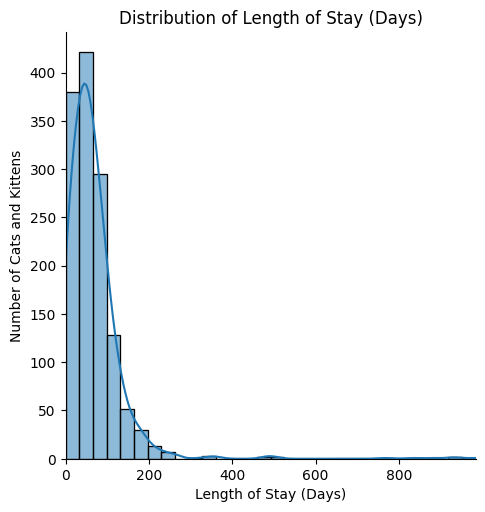

```python
# Plotting a density plot to showcase the overall distribution of 'length of stay'.
sns.displot(df_merged['Length of Stay'], kde=True, bins=30)
plt.title('Distribution of Length of Stay (Days)')
plt.xlabel('Length of Stay (Days)')
plt.xlim(df_merged['Length of Stay'].min(), df_merged['Length of Stay'].max())
plt.ylabel('Number of Cats and Kittens')

# Displaying the plot.
plt.show()
```

**Insights:**

- This **density plot** illuminates the distribution of the *length of stay* for cats and kittens at Kitty of Angels. A clear observation is the central clustering, indicating a *typical duration* most felines spend in the foster system. The distribution's **right skew** reveals that while many find homes swiftly, a subset remains for an extended time, possibly due to *individual circumstances or characteristics*. This extended tail on the right suggests **outliers**, or cats and kittens with *exceptionally prolonged stays*. Such patterns are foundational for Kitty of Angels, as understanding the typical length of stay and its variations can guide strategies to **optimize operations**. This foundational knowledge serves as a basis for deeper investigations into factors like *sex, breed*, and *intake year*, aiming to ensure the majority find homes within the most common durations.

### **5.3:** Bivariate Analysis

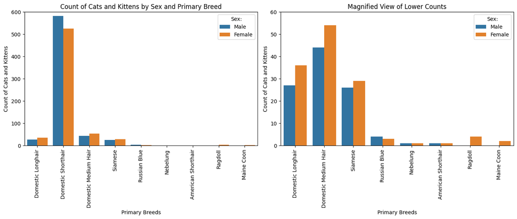

```python
# Creating a figure and subplot grid.
fig, ax = plt.subplots(1, 2, figsize=(14, 6))

# Plotting a main plot of a bar chart, displaying the count of cats based on 'Sex' and 'Primary Breed'.
sns.countplot(data=df_merged, x='Primary Breed', hue='Sex', ax=ax[0])
ax[0].set_title('Count of Cats and Kittens by Sex and Primary Breed')
ax[0].set_xlabel('Primary Breeds')
ax[0].set_ylabel('Count of Cats and Kittens')
ax[0].set_ylim(0, 600)
ax[0].legend(title='Sex:', loc='upper right')
ax[0].tick_params(axis='x', rotation=90)

# Plotting a magnified view of the lower counts of the 'Number of Cats and Kittens' on the y-axis.
filtered_df = df_merged[df_merged['Primary Breed'] != 'Domestic Shorthair']
sns.countplot(data=filtered_df, x='Primary Breed', hue='Sex', ax=ax[1])
ax[1].set_title('Magnified View of Lower Counts')
ax[1].set_xlabel('Primary Breeds')
ax[1].set_ylabel('Count of Cats and Kittens')
ax[1].set_ylim(0, 60)
ax[1].legend(title='Sex:', loc='upper right')
ax[1].tick_params(axis='x', rotation=90)

# Displaying the plots.
plt.tight_layout()
plt.show()
```

**Insights:**

- The **subplot grid** presents two count plots detailing the distribution of cats and kittens based on their *primary breed* and *sex*.

  In the **main plot** on the left, we observe the distribution across various breeds. The *Domestic Shorthair* breed significantly dominates the counts, overshadowing other breeds. Both male and female counts within this breed are notably high, suggesting its prevalent presence in the Kitty of Angels foster system.

  From these plots, it's evident that while some breeds have an approximately even distribution of male and female cats, others might show slight variations. Recognizing these patterns can be crucial for Kitty of Angels to understand breed and gender preferences, potentially aiding in targeted adoption campaigns or care strategies.

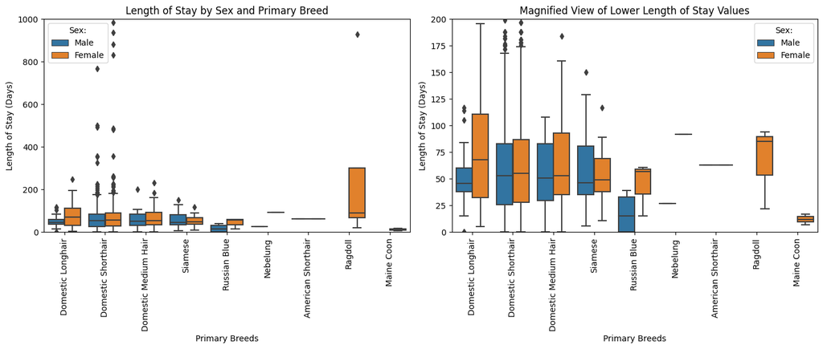

```python
# Creating a figure and subplot grid.
fig, ax = plt.subplots(1, 2, figsize=(14, 6))

# Plotting boxplots, displaying the 'Length of Stay' distribution by 'Sex' and 'Primary Breed'.
sns.boxplot(data=df_merged, x='Primary Breed', y='Length of Stay', hue='Sex', ax=ax[0])
ax[0].set_title('Length of Stay by Sex and Primary Breed')
ax[0].set_xlabel('Primary Breeds')
ax[0].set_ylabel('Length of Stay (Days)')
ax[0].set_ylim(0, 1000)
ax[0].legend(title='Sex:', loc='upper left')
ax[0].tick_params(axis='x', rotation=90)

# Plotting the magnified view of the lower 'Length of Stay' values on the y-axis.
filtered_LOS = df_merged[df_merged['Length of Stay'] < 200]
sns.boxplot(data=filtered_LOS, x='Primary Breed', y='Length of Stay', hue='Sex', ax=ax[1])
ax[1].set_title('Magnified View of Lower Length of Stay Values')
ax[1].set_xlabel('Primary Breeds')
ax[1].set_ylabel('Length of Stay (Days)')
ax[1].set_ylim(0, 200)
ax[1].legend(title='Sex:', loc='upper right')
ax[1].tick_params(axis='x', rotation=90)

# Displaying the plots.
plt.tight_layout()
plt.show()
```

**Insights:**

- These **boxplots** offer insights into the *length of stay* distribution across different *primary breeds*, categorized by *sex*.

  The **primary boxplot** on the left illustrates the spread of the *length of stay* for various breeds. It provides metrics like the median, quartiles, and potential outliers. For many breeds, we see varying distributions of stay lengths for both males and females. Some breeds, such as the *Domestic Shorthair*, exhibit wide interquartile ranges, suggesting diverse lengths of stays, while others have more compact boxes, indicating consistency.

  The **magnified view** on the right focuses on the *length of stay* values below 200 days. This refined view is especially helpful for breeds with shorter stays, allowing for clearer differentiation among breeds and sexes. It's evident that while some breeds exhibit similar distributions for both males and females, others showcase slight discrepancies.

  These plots are crucial for Kitty of Angels as they highlight not just the typical *length of stay* for each breed, but also the variability and potential outliers. Recognizing these patterns can help in formulating strategies tailored to specific breeds and sexes, ensuring optimized care and quicker adoptions.

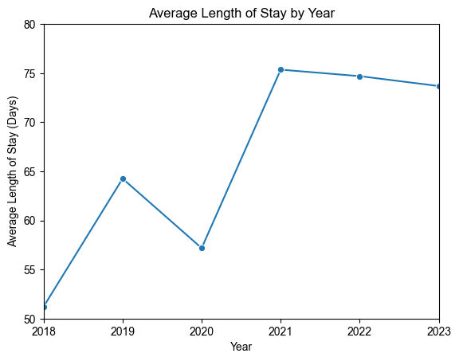

```python
# Extracting the year from the 'Outcome Date'.
df_merged['Year'] = df_merged['Outcome Date'].dt.year

# Grouping by year and calculating the mean.
yearly_average = df_merged.groupby('Year')['Length of Stay'].mean().reset_index()

# Plotting a time series plot, showcasing the 'Length of Stay' from 2017 to 2023.
sns.lineplot(data=yearly_average, x='Year', y='Length of Stay', marker='o')
sns.set_style('darkgrid')
plt.title('Average Length of Stay by Year')
plt.xlabel('Year')
plt.ylabel('Average Length of Stay (Days)')
plt.xlim(2018, 2023)
plt.ylim(50, 80)

# Displaying the plot.
plt.show()
```

**Insights:**

  From the plot, we observe a **trending pattern** in the *length of stay* over the years. There's a noticeable rise and fall, with specific years showcasing a peak in the average length. Such patterns can be influenced by multiple external and internal factors, from changes in adoption strategies, public awareness campaigns, to broader societal shifts affecting adoption rates.

  The plot shows that while there were years with a heightened average length of stay, subsequent years might have seen improvements, leading to a decrease. This fluctuation indicates the dynamic nature of the foster system and the impact of Kitty of Angels' initiatives and external influences.

  Understanding these annual patterns is essential for Kitty of Angels. It provides insights into the effectiveness of past strategies and offers a foundation to anticipate future trends, helping in the formulation of informed strategies for the coming years to ensure quicker adoptions and shorter stays.

### **5.4:** Multivariate Analysis

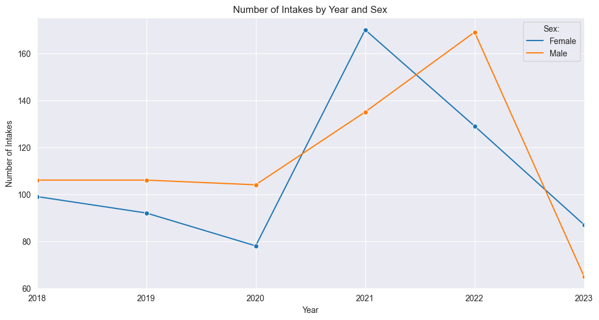

```python
# Extracting the year from the 'Intake Date'.
df_merged['Year'] = df_merged['Intake Date'].dt.year

# Grouping by year and sex and calculating the counts.
intake_counts = df_merged.groupby(['Year', 'Sex']).size().reset_index(name='Count')

# Plotting a time series plot, with separate lines from male and female cats, showing the number of 'intakes' over the years.
plt.figure(figsize=(12, 6))
sns.lineplot(data=intake_counts, x='Year', y='Count', hue='Sex', marker='o')
sns.set_style('darkgrid')
plt.title('Number of Intakes by Year and Sex')
plt.xlabel('Year')
plt.xlim(2018, 2023)
plt.ylabel('Number of Intakes')
plt.legend(title='Sex:')

# Displaying the plot.
plt.show()
```

**Insights:**

  From the plot, we discern **distinct trends** for both male and female cats. While both sexes exhibit some similarities in their intake patterns, certain years show noticeable disparities in the counts. The presence of these peaks and troughs suggests varying dynamics in the intake of male and female felines, possibly influenced by a range of factors, from breeding patterns, rescues, or shifts in public preference.

  Furthermore, it's evident that in some years, the intake of one sex surpasses the other, potentially highlighting sex-specific challenges or opportunities faced by Kitty of Angels during those periods.

  For Kitty of Angels, understanding these sex-based intake patterns is invaluable. It aids in recognizing sex-specific needs, challenges, or preferences, enabling the formulation of targeted campaigns, care strategies, or adoption drives, ensuring that both male and female felines receive the best possible care and adoption opportunities.

### **5.2:** Reflection

- Given more time for this project, I would dive deeper into the potential data quality issues, particularly investigating the presence of outliers and ensuring data consistency across years. I'd explore structural relationships between variables, such as whether certain breeds have seasonality in their intake patterns or if specific events influenced the peaks in average length of stay. A further avenue would be to analyze the correlation between length of stay and other potential variables not covered, like age or health conditions of the cats. Lastly, I'd eventually aim to build a predictive model to forecast future intakes and stays, assisting Kitty of Angels in proactive planning and resource allocation.